# Titanic Survival Prediction

```python
import pandas as pd
import numpy as np
from sklearn.metrics import f1_score, accuracy_score, confusion_matrix, classification_report
from sklearn.model_selection import train_test_split
from sklearn.ensemble import RandomForestClassifier
from sklearn.preprocessing import StandardScaler
from sklearn.metrics import roc_curve, auc
from category_encoders import TargetEncoder

import matplotlib.pyplot as plt
from xgboost import XGBClassifier
from xgboost import plot_importance
from sklearn.linear_model import LogisticRegression
import seaborn as sns
sns.set_style('whitegrid')

%matplotlib inline
plt.rcParams['figure.figsize'] = (10, 6)
```

## 1. Data Exploration and Cleaning

```python
df_train = pd.read_csv('train.csv')
df_submission_test = pd.read_csv('test.csv')
```

```python
passenger_id = df_submission_test['PassengerId']
target = df_train['Survived']

df_train.drop(['PassengerId'], axis=1,inplace=True)
df_submission_test.drop(['PassengerId'], axis=1,inplace=True)

df_all = pd.concat([df_train.drop('Survived', axis=1), df_submission_test]).reset_index(drop=True)

ntrain = df_train.shape[0]
ntest = df_submission_test.shape[0]
```

```python
df_all.head(10)
```

|  | Pclass | Name | Sex | Age | SibSp | Parch | Ticket | Fare | Cabin | Embarked |
| --- | --- | --- | --- | --- | --- | --- | --- | --- | --- | --- |
| 0 | 3 | Braund, Mr. Owen Harris | male | 22.00 | 1 | 0 | A/5 21171 | 7.25 | NaN | S |
| 1 | 1 | Cumings, Mrs. John Bradley (Florence Briggs Th... | female | 38.00 | 1 | 0 | PC 17599 | 71.28 | C85 | C |
| 2 | 3 | Heikkinen, Miss. Laina | female | 26.00 | 0 | 0 | STON/O2. 3101282 | 7.92 | NaN | S |
| 3 | 1 | Futrelle, Mrs. Jacques Heath (Lily May Peel) | female | 35.00 | 1 | 0 | 113803 | 53.10 | C123 | S |
| 4 | 3 | Allen, Mr. William Henry | male | 35.00 | 0 | 0 | 373450 | 8.05 | NaN | S |
| 5 | 3 | Moran, Mr. James | male | NaN | 0 | 0 | 330877 | 8.46 | NaN | Q |
| 6 | 1 | McCarthy, Mr. Timothy J | male | 54.00 | 0 | 0 | 17463 | 51.86 | E46 | S |
| 7 | 3 | Palsson, Master. Gosta Leonard | male | 2.00 | 3 | 1 | 349909 | 21.07 | NaN | S |
| 8 | 3 | Johnson, Mrs. Oscar W (Elisabeth Vilhelmina Berg) | female | 27.00 | 0 | 2 | 347742 | 11.13 | NaN | S |
| 9 | 2 | Nasser, Mrs. Nicholas (Adele Achem) | female | 14.00 | 1 | 0 | 237736 | 30.07 | NaN | C |

Let's start by looking at the distribution of the survival of the passengers

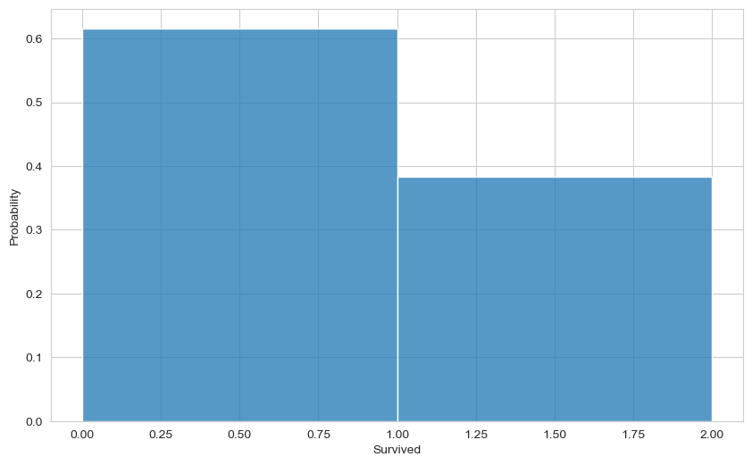

```python
sns.histplot(x='Survived', data=df_train, bins=[0,1,2], stat='probability')
```

Looks like the survival rate is around 38% and the dataset is unbalanced, shifted towards not surviving.

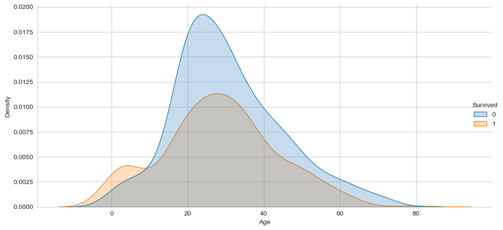

```python
facet = sns.displot(df_train, x='Age', hue="Survived", aspect=2, height=5, kind="kde", fill=True)
facet.add_legend()
```

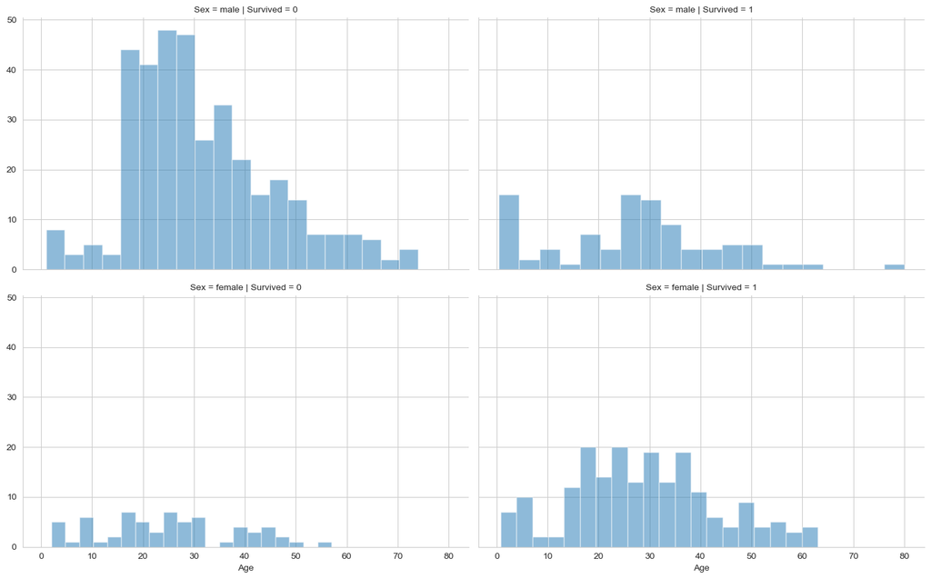

```python
# Investigate survivorship by gender and age
grid = sns.FacetGrid(df_train, row='Sex', col='Survived', height=4.5, aspect=1.6)
grid.map(plt.hist, 'Age', alpha=0.5, bins=20)
```

Generally we have a larger male percentage of the passengers who don't survive. This makes sense as women and children were given priority to the lifeboats.

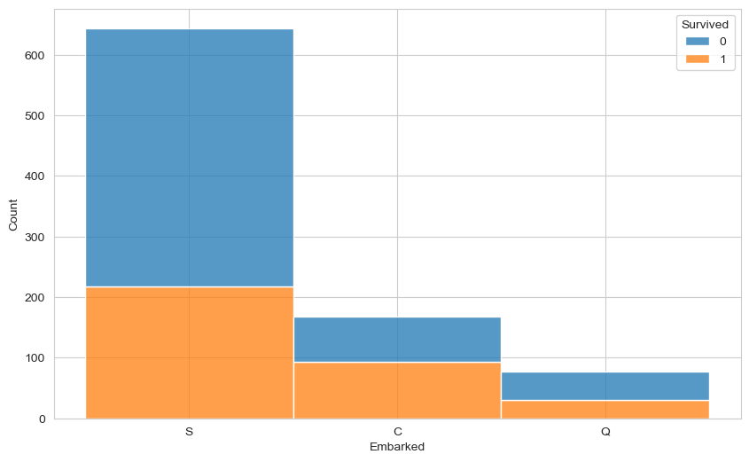

```python
sns.histplot(data=df_train, x="Embarked", hue="Survived", multiple="stack")
```

### Embarked

Embarked has two missing values

```python
print(set(list(df_all['Embarked'])))
print(df_all['Embarked'].isna().sum())
df_all[df_all['Embarked'].isna()]
```

```
{nan, 'S', 'C', 'Q'}
2
```

|  | Pclass | Name | Sex | Age | SibSp | Parch | Ticket | Fare | Cabin | Embarked |
| --- | --- | --- | --- | --- | --- | --- | --- | --- | --- | --- |
| 61 | 1 | Icard, Miss. Amelie | female | 38.0 | 0 | 0 | 113572 | 80.0 | B28 | NaN |
| 829 | 1 | Stone, Mrs. George Nelson (Martha Evelyn) | female | 62.0 | 0 | 0 | 113572 | 80.0 | B28 | NaN |

These are filled in by looking up the names of the passengers on the internet

```python
# https://www.encyclopedia-titanica.org/titanic-survivor/amelia-icard.html
df_all.loc[df_all.Name == 'Icard, Miss. Amelie', 'Embarked'] = 'S'
# https://www.encyclopedia-titanica.org/titanic-survivor/amelia-icard.html
df_all.loc[df_all.Name == 'Stone, Mrs. George Nelson (Martha Evelyn)', 'Embarked'] = 'S'
```

```python
# One hot encode embarked
df_all = pd.get_dummies(df_all, columns=['Embarked'], drop_first=True)
```

### Age

We will fill the missing values in Age after we have created a new feature called Title

### Cabin

```python
df_all['Deck'] = df_all['Cabin'].str[0]
df_all['Deck'] = df_all['Deck'].fillna('U')
```

```python
df_all['Deck'].value_counts()
```

```
U    1014
C      94
B      65
D      46
E      41
A      22
F      21
G       5
T       1
Name: Deck, dtype: int64
```

Multiple passengers can have the same ticket number. Find tickets where some passengers have a non-nan deck value and others have a nan deck value.

```python
ticket_list = []
for ticket_id in list(df_all['Ticket'].unique()):

    count = df_all[df_all['Ticket']==ticket_id].count()[0]
    decks = df_all[df_all['Ticket']==ticket_id]['Deck']
    empty_decks = (decks=='U').sum()

    if (count > 1) and (empty_decks > 0) and (empty_decks < len(decks)):
        ticket_list.append(ticket_id)

print(ticket_list)
```

```
['2668', 'PC 17755', 'PC 17760', '19877', '113781', '17421', 'PC 17608', '36928', 'PC 17757', 'PC 17761', '24160', 'S.O./P.P. 3']
```

```python
ticket_deck_dict = df_all[(df_all.Deck != 'U') & (df_all['Ticket'].isin(ticket_list))].groupby('Ticket').Deck.unique().to_dict()
pd.DataFrame(ticket_deck_dict)
```

|  | 113781 | 17421 | 19877 | 24160 | 2668 | 36928 | PC 17608 | PC 17755 | PC 17757 | PC 17760 | PC 17761 | S.O./P.P. 3 |
| --- | --- | --- | --- | --- | --- | --- | --- | --- | --- | --- | --- | --- |
| 0 | C | C | C | B | F | C | B | B | C | C | C | E |

```python
for ticket, deck in ticket_deck_dict.items():
    df_all.loc[df_all['Ticket']==ticket, 'Deck'] = deck[0]
df_all[(df_all.Deck == 'U') & (df_all['Ticket'].isin(ticket_list))]
```

|  | Pclass | Name | Sex | Age | SibSp | Parch | Ticket | Fare | Cabin | Embarked_Q | Embarked_S | Deck |
| --- | --- | --- | --- | --- | --- | --- | --- | --- | --- | --- | --- | --- |

```python
# ticket ID, information https://www.kaggle.com/code/gbellport/simple-titanic-data-analysis-w-cabin

# 2668, 2 siblings (sharing with mother)
df_all.at[533,'Deck'] = df_all.at[128,'Deck']
df_all.at[1308,'Deck'] = df_all.at[128,'Deck']

# PC 17755, maid to Mrs. Cardeza
df_all.at[258,'Deck'] = df_all.at[679,'Deck']

# PC 17760, manservant to Mrs White
df_all.at[373,'Deck'] = 'C'

# 19877, maid to Mrs Cavendish
df_all.at[290,'Deck'] = df_all.at[741,'Deck']

# 113781, maid and nurse to the Allisons
df_all.at[708,'Deck'] = df_all.at[297,'Deck']
df_all.at[1032,'Deck'] = df_all.at[297,'Deck']

# 17421, maid to Mrs Thayer
df_all.at[306,'Deck'] = 'C'

# PC 17608, governess (teacher) to Master Ryerson
df_all.at[1266,'Deck'] = df_all.at[1033,'Deck']

# 36928, parents (sharing with daughters)
df_all.at[856,'Deck'] = df_all.at[318,'Deck']
df_all.at[1108,'Deck'] = df_all.at[318,'Deck']

# PC 17757, maid and manservant to the Astors
df_all.at[380,'Deck'] = 'C'
df_all.at[557,'Deck'] = 'C'

# PC 17761, maid to Mrs Douglas, occupied room with another maid
df_all.at[537,'Deck'] = 'C'

# 24160, maid to Mrs. Robert, testimony that she was on deck E
df_all.at[1215,'Deck'] = 'E'

# S.O./P.P. 3, very little information, will assume on deck E with Mrs. Mack
df_all.at[841,'Deck'] = df_all.at[772,'Deck']
```

```python
df_all.Deck.value_counts()
```

```
U    998
C    104
B     67
D     46
E     43
F     23
A     22
G      5
T      1
Name: Deck, dtype: int64
```

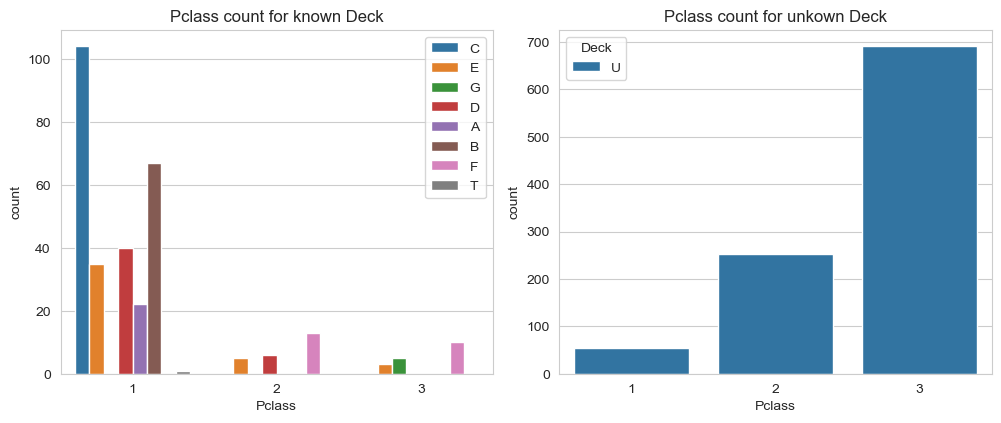

```python
fig,ax = plt.subplots(1,2,figsize = (10,4))
plt.tight_layout(w_pad=2)
ax = ax.ravel()

sns.countplot(x='Pclass',data=df_all[df_all['Deck']!='U'],hue='Deck',ax=ax[0])
ax[0].legend(loc=1)
ax[0].set_title('Pclass count for known Deck')
sns.countplot(x='Pclass',data=df_all[df_all['Deck']=='U'],hue='Deck',ax=ax[1])
ax[1].set_title('Pclass count for unkown Deck')
```

3rd class passengers were on the lower levels of the Titanic, mainly E,F, and G decks. The T deck only housing 1 person

```python
decks_by_class = [[],[],[]]
for i in range(3):
    decks_by_class[i] = list(df_all[df_all['Pclass']==i+1]['Deck'].unique())
    print(f'Pclass = {i+1} decks:',decks_by_class[i])
```

```
Pclass = 1 decks: ['C', 'E', 'A', 'U', 'B', 'D', 'T']
Pclass = 2 decks: ['U', 'D', 'F', 'E']
Pclass = 3 decks: ['U', 'G', 'F', 'E']
```

```python
# Removing unknown ('U') entries and single 'T' cabin
for i in range(3):
    if 'U' in decks_by_class[i]:
        decks_by_class[i].remove('U')
    if 'T' in decks_by_class[i]:
        decks_by_class[i].remove('T')
```

```python
weights_by_class = [[],[],[]]

for i,deck_list in enumerate(decks_by_class):
    for deck in deck_list:
        if i == 0:
            class_total = df_all[(df_all['Deck']!='U')&(df_all['Pclass']==i+1)].count()[0]-1
        else:
            class_total = df_all[(df_all['Deck']!='U')&(df_all['Pclass']==i+1)].count()[0]
        deck_total = df_all[(df_all['Deck']==deck)&(df_all['Pclass']==i+1)].count()[0]
        weights_by_class[i].append(deck_total/class_total)
    print(f'Pclass = {i+1} weights:',np.round(weights_by_class[i],3))
```

```
Pclass = 1 weights: [0.388 0.131 0.082 0.25  0.149]
Pclass = 2 weights: [0.25  0.542 0.208]
Pclass = 3 weights: [0.278 0.556 0.167]
```

```python
ticket_dict = {}
def impute_deck(row):

    ticket = row['Ticket']
    deck = row['Deck']
    pclass = row['Pclass']

    if (deck == 'U') and (ticket not in ticket_dict):

        if pclass == 1:
            deck = list(np.random.choice(decks_by_class[0],size=1,
                                         p=weights_by_class[0]))[0]
        elif pclass ==2:
            deck = list(np.random.choice(decks_by_class[1],size=1,
                                         p=weights_by_class[1]))[0]
        elif pclass ==3:
            deck = list(np.random.choice(decks_by_class[2],size=1,
                                         p=weights_by_class[2]))[0]

        ticket_dict[ticket] = deck

    elif (deck == 'U') and (ticket in ticket_dict):
        deck = ticket_dict[ticket]

    return deck
df_all['Deck'] = df_all.apply(impute_deck,axis=1)
```

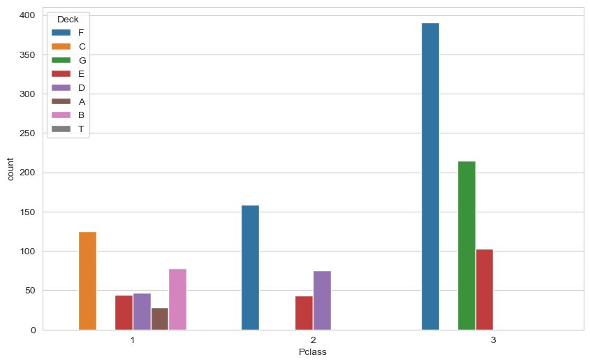

```python
sns.countplot(x='Pclass',data=df_all, hue='Deck')
```

### Fare per person

```python
def extract_ticket_ref(ticket):
    split_ticket = ticket.split()
    return split_ticket[0] if len(split_ticket) > 1 else 0

def extract_ticket_number(ticket):
    return ticket.split()[-1]

# Apply functions to 'Ticket' column
df_all['Ticket_ref'] = df_all['Ticket'].apply(extract_ticket_ref)
df_all['Ticket_number'] = df_all['Ticket'].apply(extract_ticket_number)
```

```python
df_all["LastName"] = df_all["Name"].apply(lambda x: x.split(',')[0])
```

```python
ticket_dict = df_all.groupby('Ticket_number').LastName.count().to_dict() #create dict grouped by people with the same ticket and surname
df_all['Same_ticket'] = df_all.Ticket_number.map(ticket_dict) # Number of people with the same ticket.
df_all['Price_paid'] = (df_all.Fare / df_all['Same_ticket'])# Price payed per person
```

```
Deck
B    650.442819
A    166.902369
C    105.464190
D    103.990788
E     74.797786
F      7.653086
G      1.668891
Name: Price_paid, dtype: float64
```

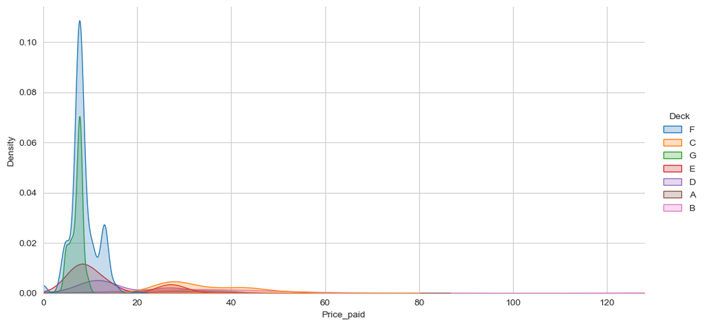

```python
sns.displot(df_all[df_all.Deck != 'T'],x='Price_paid',hue='Deck',kind='kde',fill=True, aspect=2)
plt.xlim(0,df_all.Price_paid.max())
df_all[df_all.Deck != 'T'].groupby("Deck").Price_paid.var().sort_values(ascending=False)
```

```python
for deck in df_all.Deck.unique():
    df_all.loc[(df_all.Deck == deck) & (df_all.Price_paid == 0 ), 'Price_paid'] = df_all[df_all.Deck == deck].Price_paid.mean()
```

```
(0.0, 128.0823)
```

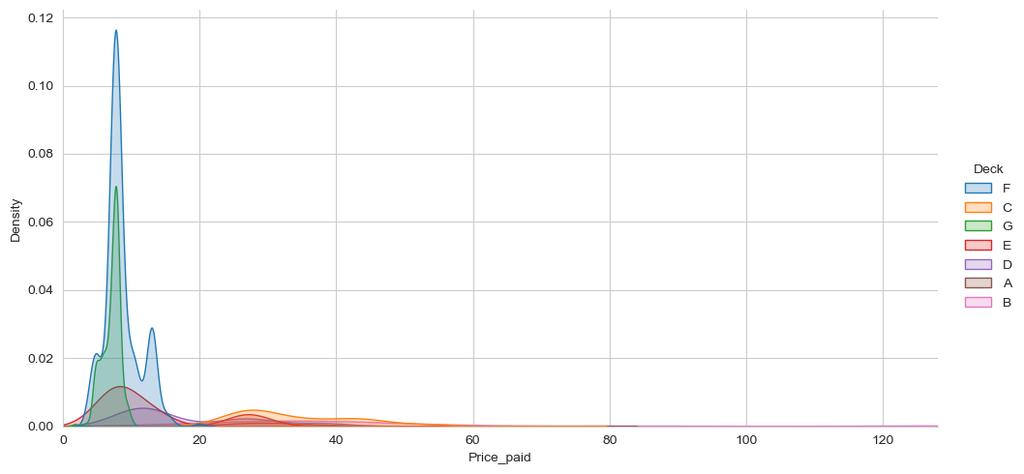

```python
sns.displot(df_all[df_all.Deck != 'T'],x='Price_paid',hue='Deck',kind='kde',fill=True, aspect=2)
plt.xlim(0,df_all.Price_paid.max())
```

There's some large values for Price_paid on deck B

```python
print(df_all[(df_all.Deck == 'B')]['Price_paid'].sort_values(ascending=True).head(10))
print(df_all[(df_all.Deck == 'B')]['Price_paid'].sort_values(ascending=False).head(10))
```

```
872      5.000
1035    13.275
690     19.000
781     19.000
520     23.375
1199    23.375
820     23.375
1281    23.375
1294    23.550
83      23.550
Name: Price_paid, dtype: float64
737     128.082300
679     128.082300
1234    128.082300
258     128.082300
299      82.506933
118      82.506933
1075     82.506933
779      52.834375
730      52.834375
689      52.834375
Name: Price_paid, dtype: float64
```

```python
df_all.loc[(df_all['Deck'] == 'B') & (df_all['Price_paid'] < 19), 'Price_paid'] = 19 #outlier reduction
df_all.loc[(df_all['Deck'] == 'B') & (df_all['Price_paid'] >= 82.5), 'Price_paid'] = 82.5 #outlier reduction
```

```
(0.0, 82.5)
```

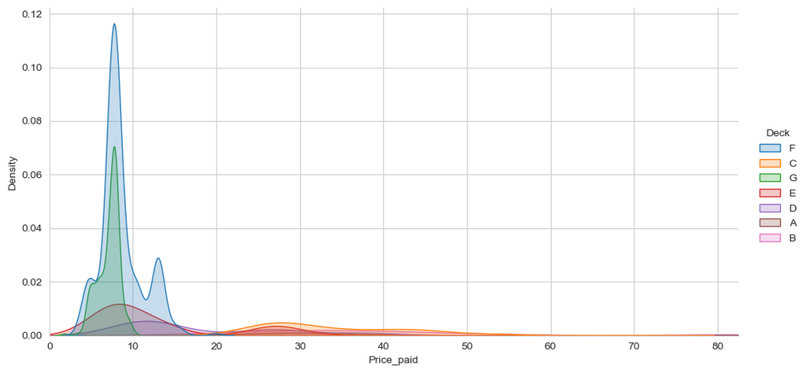

```python
sns.displot(df_all[df_all.Deck != 'T'],x='Price_paid',hue='Deck',kind='kde',fill=True, aspect=2)
plt.xlim(0,df_all.Price_paid.max())
```

```python
df_all[df_all.Price_paid.isna()]
```

|  | Pclass | Name | Sex | Age | SibSp | Parch | Ticket | Fare | Cabin | Embarked_Q | Embarked_S | Deck | Ticket_ref | Ticket_number | LastName | Same_ticket | Price_paid |
| --- | --- | --- | --- | --- | --- | --- | --- | --- | --- | --- | --- | --- | --- | --- | --- | --- | --- |
| 1043 | 3 | Storey, Mr. Thomas | male | 60.5 | 0 | 0 | 3701 | NaN | NaN | 0 | 1 | F | 0 | 3701 | Storey | 1 | NaN |

```python
df_all.loc[1043, 'Price_paid'] = df_all[(df_all.Deck == 'F') & (df_all.Embarked_S == 1)]['Price_paid'].mean().round(1)
```

## 3. Feature Engineering

### Family size

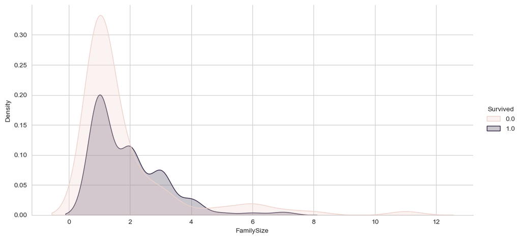

```python
df_all["FamilySize"] = df_all["SibSp"] + df_all["Parch"] + 1

df_tmp = df_all.copy()
df_tmp['Survived'] = target
sns.displot(df_tmp, x="FamilySize", hue="Survived", kind="kde", fill=True, aspect=2)
del df_tmp
```

Seems like passengers with large families had a lower chance of survival

```python
df_all["HasLargeFamily"] = (df_all["FamilySize"] >= 4).astype(int)
df_all["IsAlone"] = (df_all["FamilySize"] == 1).astype(int)
```

```python
df_all['IsTravellingWithParents'] = ((df_all['Parch'] > 0)).astype(int)
```

### Gender

Convert gender to one-hot K-1 encoding

```python
df_all = pd.get_dummies(df_all, columns=['Sex'], drop_first=True)
```

### Titles

```python
def add_title(df):
    df['Title'] = df["Name"].str.extract('([A-Za-z]+)\.',expand=False)
    df.Title = df.Title.str.replace('Mme', 'Mrs')
    df.Title = df.Title.str.replace('Mlle', 'Miss')
    df.Title = df.Title.str.replace('Jonkheer', 'Mr')
    return df

df_all = add_title(df_all)


# Count the number of people with each title
rarity = df_all.Title.value_counts()
rarity
```

```
Mr          758
Miss        262
Mrs         198
Master       61
Rev           8
Dr            8
Col           4
Ms            2
Major         2
Don           1
Lady          1
Sir           1
Capt          1
Countess      1
Dona          1
Name: Title, dtype: int64
```

```python
df_all.head()
```

|  | Pclass | Name | Age | SibSp | Parch | Ticket | Fare | Cabin | Embarked_Q | Embarked_S | ... | Ticket_number | LastName | Same_ticket | Price_paid | FamilySize | HasLargeFamily | IsAlone | IsTravellingWithParents | Sex_male | Title |
| --- | --- | --- | --- | --- | --- | --- | --- | --- | --- | --- | --- | --- | --- | --- | --- | --- | --- | --- | --- | --- | --- |
| 0 | 3 | Braund, Mr. Owen Harris | 22.0 | 1 | 0 | A/5 21171 | 7.2500 | NaN | 0 | 1 | ... | 21171 | Braund | 1 | 7.25000 | 2 | 0 | 0 | 0 | 1 | Mr |
| 1 | 1 | Cumings, Mrs. John Bradley (Florence Briggs Th... | 38.0 | 1 | 0 | PC 17599 | 71.2833 | C85 | 0 | 0 | ... | 17599 | Cumings | 2 | 35.64165 | 2 | 0 | 0 | 0 | 0 | Mrs |
| 2 | 3 | Heikkinen, Miss. Laina | 26.0 | 0 | 0 | STON/O2. 3101282 | 7.9250 | NaN | 0 | 1 | ... | 3101282 | Heikkinen | 1 | 7.92500 | 1 | 0 | 1 | 0 | 0 | Miss |
| 3 | 1 | Futrelle, Mrs. Jacques Heath (Lily May Peel) | 35.0 | 1 | 0 | 113803 | 53.1000 | C123 | 0 | 1 | ... | 113803 | Futrelle | 2 | 26.55000 | 2 | 0 | 0 | 0 | 0 | Mrs |
| 4 | 3 | Allen, Mr. William Henry | 35.0 | 0 | 0 | 373450 | 8.0500 | NaN | 0 | 1 | ... | 373450 | Allen | 1 | 8.05000 | 1 | 0 | 1 | 0 | 1 | Mr |

5 rows × 22 columns

```python
# These titles are very rare, so we'll combine them with the more common ones.
titles = ['Dr', 'Rev', 'Major', 'Col', 'Capt', 'Jonkheer', 'Countess', 'Sir', 'Lady', 'Don', 'Dona']
df_all.loc[(df_all['Title'].isin(titles)) & (df_all['Sex_male'] == 1), 'Title'] = 'Mr'
df_all.loc[(df_all['Title'].isin(titles)) & (df_all['Sex_male'] == 0), 'Title'] = 'Mrs'
```

"Master" was typically used to address young men, like Miss for girls

| Title | count | mean | std | min | 25% | 50% | 75% | max |
| --- | --- | --- | --- | --- | --- | --- | --- | --- |
| Master | 53.0 | 5.482642 | 4.161554 | 0.33 | 2.0 | 4.0 | 9.0 | 14.5 |
| Mr | 605.0 | 32.784298 | 12.657066 | 11.00 | 23.0 | 30.0 | 40.0 | 80.0 |

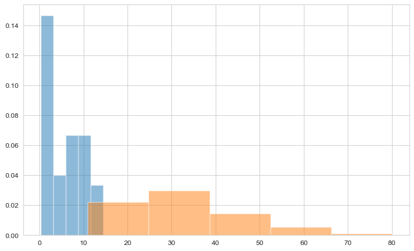

```python
men_titles = df_all[(df_all.Title == 'Master')  | (df_all.Title == 'Mr')].groupby('Title').Age

men_titles.hist(density=True, alpha=0.5, bins=5)
men_titles.describe()
```

Create a clear distinction between young and old men

```python
df_all.loc[((df_all.Title == 'Mr') & (df_all['Age'] <= 17)), 'Title'] = 'Master'
df_all.loc[((df_all['Title'] == 'Master') & (df_all['Age'] > 17)), 'Title'] = 'Mr'
```

| Title | count | mean | std | min | 25% | 50% | 75% | max |
| --- | --- | --- | --- | --- | --- | --- | --- | --- |
| Miss | 212.0 | 21.795236 | 12.192794 | 0.17 | 15.0 | 22.0 | 30.0 | 63.0 |
| Mrs | 175.0 | 37.040000 | 12.817176 | 14.00 | 27.0 | 36.0 | 47.0 | 76.0 |

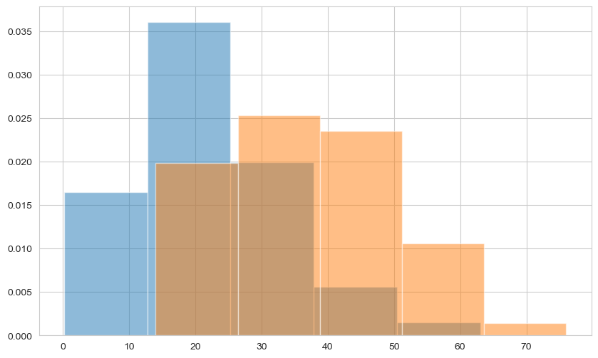

```python
women_titles = df_all[(df_all.Title == 'Miss')  | (df_all.Title == 'Mrs')].groupby('Title').Age

women_titles.hist(density=True, alpha=0.5, bins=5)
women_titles.describe()
```

As we see, there's lacking clear distinct in these titles

```python
df_all.loc[((df_all.Title == 'Mrs') & (df_all.Age <= 17)), 'Title'] = 'Miss'
df_all.loc[((df_all.Title == 'Miss') & (df_all.Age > 30)), 'Title'] = 'Ms'
```

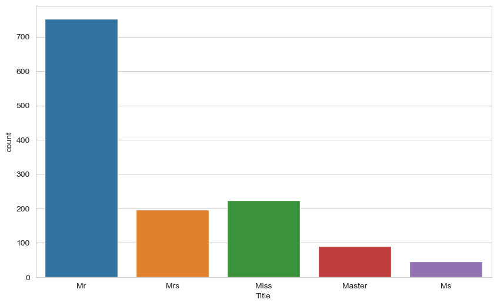

```python
sns.countplot(x='Title',data=df_all)
```

```python
# https://www.kaggle.com/code/eu1234/titanic-81-57-leaderboard-top-1-no-cheating
df_tmp = df_all.copy()
df_tmp['Survived'] = target

family_survivers = df_tmp[['LastName', 'Survived']].groupby('LastName').mean().round(2).reset_index()
family_survivers.groupby(['LastName', 'Survived']).mean().sort_values('Survived', ascending=False)[:10]
```

| LastName | Survived |
| --- | --- |
| Lehmann | 1.0 |
| Glynn | 1.0 |
| Hedman | 1.0 |
| Healy | 1.0 |
| Hays | 1.0 |
| Hawksford | 1.0 |
| Hassab | 1.0 |
| Ryerson | 1.0 |
| Saalfeld | 1.0 |
| Harder | 1.0 |

```python
# https://www.kaggle.com/code/eu1234/titanic-81-57-leaderboard-top-1-no-cheating
family_survivers_dict = dict(zip(family_survivers.LastName, family_survivers.Survived))

common_survivers = {}
for surname, survived in family_survivers_dict.items():
    # A surname is common if it's present in the test set
    if surname in list(df_all[df_tmp.Survived.isna()]['LastName'].unique()):
        common_survivers[surname] = survived

df_all['Family_survivers'] = df_all.LastName.map(common_survivers)
df_all.Family_survivers = df_all.Family_survivers.fillna(df_all.Family_survivers.mean())
```

### Status

```python
def add_status(df):
    df.loc[(df['Sex_male'] == 0) & (df['Parch'] > 0), 'Status'] = 'Mother'
    df.loc[(df['Sex_male'] == 1) & (df['Parch'] > 0), 'Status'] = 'Father'
    df.loc[(df['Sex_male'] == 0) & (df['Parch'] == 0), 'Status'] = 'Woman'
    df.loc[(df['Sex_male'] == 1) & (df['Parch'] == 0), 'Status'] = 'Man'
    df.loc[df['Title'] == 'Master', 'Status'] = 'Child'
    df.loc[df['Age'] <= 17, 'Status'] = 'Child'
    return df

df_all = add_status(df_all)
```

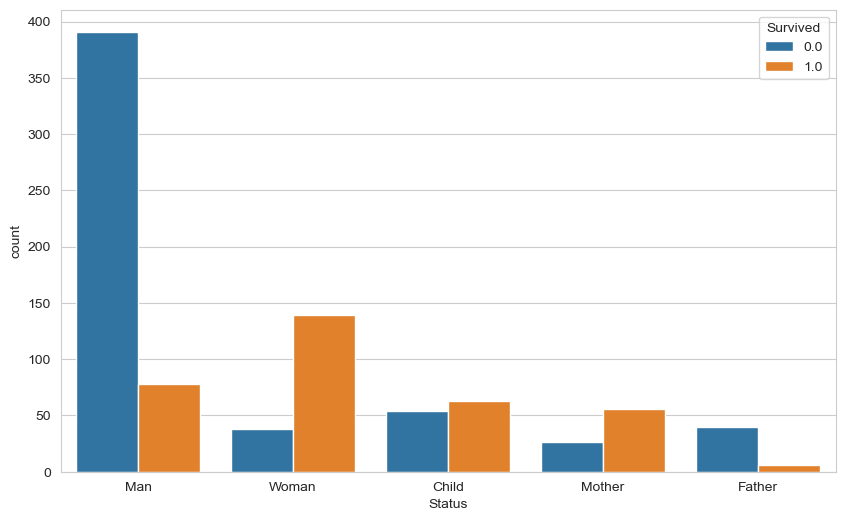

```python
df_tmp = df_all.copy()
df_tmp['Survived'] = target

sns.countplot(data=df_tmp, x='Status', hue='Survived')
del df_tmp
```

## Interpolate missing ages based on titles

```python
# Find number of nan ages grouped by Title
df_all.groupby(['Pclass', 'Title', 'Status'])['Age'].apply(lambda x: x.isna().sum())
```

```
Pclass  Title   Status
1       Master  Child       0
        Miss    Child       0
                Mother      0
                Woman       1
        Mr      Father      0
                Man        28
        Mrs     Mother      1
                Woman       9
        Ms      Mother      0
                Woman       0
2       Master  Child       0
        Miss    Child       0
                Mother      0
                Woman       2
        Mr      Father      0
                Man        13
        Mrs     Mother      0
                Woman       1
        Ms      Woman       0
3       Master  Child       8
        Miss    Child       0
                Mother     10
                Woman      37
        Mr      Father      5
                Man       131
        Mrs     Mother      6
                Woman      10
        Ms      Mother      0
                Woman       1
Name: Age, dtype: int64
```

We have a single child travelling alone, so he's probably a bit older than most children.

```python
display(df_all[(df_all.Age.isnull()) & (df_all.Name.str.contains('Master')) & (df_all.Parch==0)])
df_all.loc[(df_all.Age.isnull()) & (df_all.Name.str.contains('Master')) & (df_all.Parch==0), 'Age'] = 14
```

|  | Pclass | Name | Age | SibSp | Parch | Ticket | Fare | Cabin | Embarked_Q | Embarked_S | ... | Same_ticket | Price_paid | FamilySize | HasLargeFamily | IsAlone | IsTravellingWithParents | Sex_male | Title | Family_survivers | Status |
| --- | --- | --- | --- | --- | --- | --- | --- | --- | --- | --- | --- | --- | --- | --- | --- | --- | --- | --- | --- | --- | --- |
| 1230 | 3 | Betros, Master. Seman | NaN | 0 | 0 | 2622 | 7.2292 | NaN | 0 | 0 | ... | 1 | 7.2292 | 1 | 0 | 1 | 0 | 1 | Master | 0.0 | Child |

1 rows × 24 columns

I found some of the missing ages by looking up the names of the passengers on https://www.encyclopedia-titanica.org/titanic-ages/23.html

```python
df_all.loc[df_all.Name == 'Moran, Mr. James', 'Age'] = 29

df_all.loc[df_all.Name == 'Sage, Miss. Dorothy Edith "Dolly"', 'Age'] = 14
df_all.loc[df_all.Name == 'Sage, Miss. Dorothy Edith "Dolly"', 'Status'] = 'Child'
df_all.loc[df_all.Name == 'Sage, Miss. Dorothy Edith "Dolly"', 'Title'] = 'Miss'

df_all.loc[df_all.Name == 'Peter, Master. Michael J', 'Age'] = 5

df_all.loc[df_all.Name == 'Masselmani, Mrs. Fatima', 'Age'] = 22

df_all.loc[df_all.Name == 'Emir, Mr. Farred Chehab', 'Age'] = 22

df_all.loc[df_all.Name == 'O\'Dwyer, Miss. Ellen "Nellie"', 'Age'] = 23

df_all.loc[df_all.Name == 'Todoroff, Mr. Lalio', 'Age'] = 23
df_all.loc[df_all.Name == 'Spector, Mr. Woolf', 'Age'] = 23
```

This would take too long for all the passengers, so I'll just interpolate the missing ages based on based on the median age of a groups with 'Pclass', 'Title', 'Deck' and 'IsTravellingWithParents' in common.  
I found the last to be a good indicator of lower age, as children are more likely to travel with their parents.

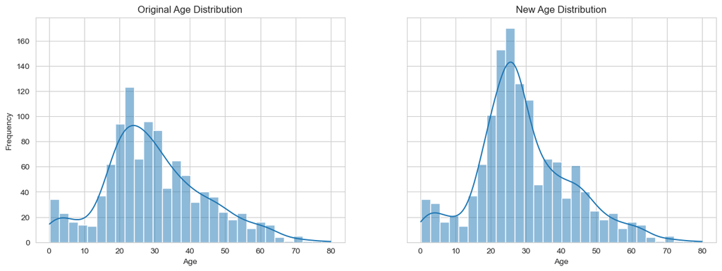

```python
fig, (ax1, ax2) = plt.subplots(1, 2, figsize=(15, 5), sharey=True)

sns.histplot(df_all['Age'].dropna(), bins=30, ax=ax1, kde=True)
ax1.set_title('Original Age Distribution')
ax1.set_xlabel('Age')
ax1.set_ylabel('Frequency')

# Fill nan ages with mean of Sex_male, Pclass and Title
# Group the data by Sex, Pclass, and Title, and then calculate the median age
median_ages = df_all.groupby(['Pclass', 'Title', 'Deck', 'IsTravellingWithParents'])['Age'].median()

# Define a function to fill missing ages
def fill_missing_age(row):
    if pd.isna(row['Age']):
        return median_ages[row['Pclass'], row['Title'], row['Deck'], row['IsTravellingWithParents']]
    else:
        return row['Age']

# Apply the function to fill missing ages
df_all['Age'] = df_all.apply(fill_missing_age, axis=1)
sns.histplot(df_all['Age'].dropna(), bins=30, ax=ax2, kde=True)
ax2.set_title('New Age Distribution')
ax2.set_xlabel('Age')
ax2.set_ylabel('Frequency')

plt.show()
```

There's quite a few more ages in the high-twenties now, which might not be ideal. Future improvements could be to train a model to predict the missing ages, or to use methods like Multivariate Imputation by Chained Equations (MICE) or MissForest.

### One hot encode Status (K-1) as to not create interdependence between the features

```python
df_all = pd.get_dummies(df_all, columns=['Status'], drop_first=True)
```

### Create age brackets

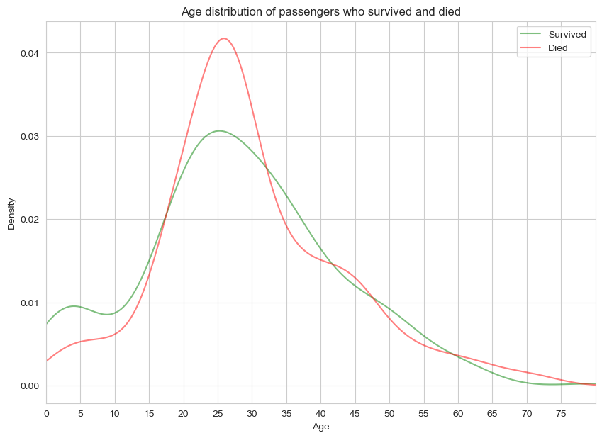

```python
df_tmp = df_all.copy()
df_tmp['Survived'] = target

df_tmp[df_tmp.Survived == 1].Age.plot(kind='kde', color='green', alpha=0.5, figsize=(10, 7), label='Survived')
df_tmp[df_tmp.Survived == 0].Age.plot(kind='kde', color='red', alpha=0.5, figsize=(10, 7), label='Died')
plt.xlim(0, df_all.Age.max())
plt.xticks(np.arange(0, df_all.Age.max(), 5))
plt.legend()
plt.xlabel("Age")
plt.title("Age distribution of passengers who survived and died")
del df_tmp
plt.show()
```

We see the some age intervals have different survival rates

```python
def create_age_brackets(df):
    # Make the age bracket an ordinal variable, so the higher the
    # probability of survival, the higher the number
    bins = [0, 18, 34, 45, 57, np.inf]
    labels = [5, 2, 4, 3, 1]
    df['AgeBracket'] = pd.cut(df['Age'], bins=bins, labels=labels).astype(int)
    return df

df_all = create_age_brackets(df_all)
```

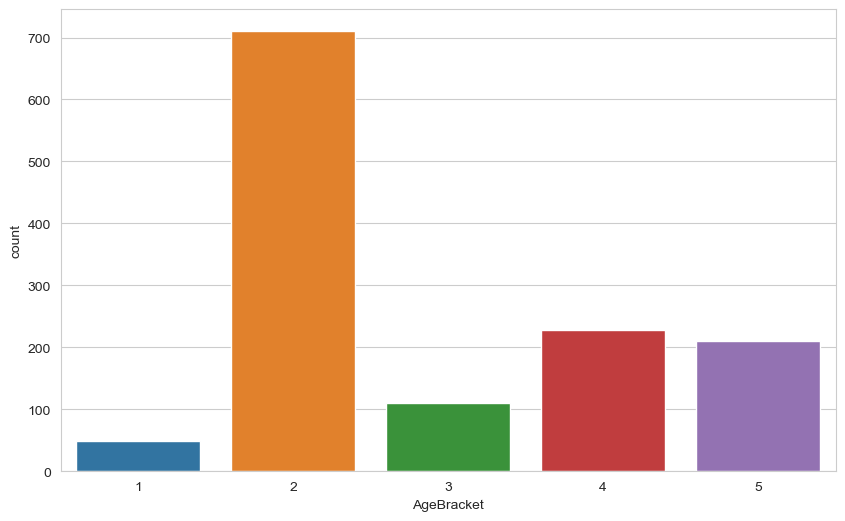

```python
sns.countplot(data=df_all, x='AgeBracket')
```

### Price_paid

Break up the price paid per passenger into intervals, as we see that the survival rate is different for different price intervals.

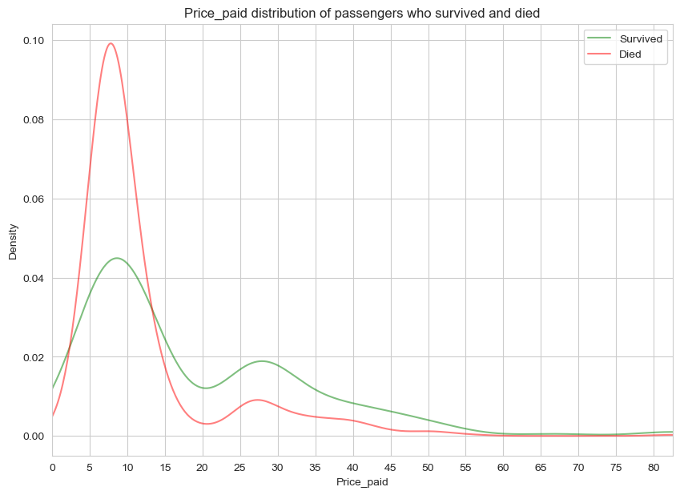

```python
df_tmp = df_all.copy()
df_tmp['Survived'] = target

df_tmp[df_tmp.Survived == 1].Price_paid.plot(kind='kde', color='green', alpha=0.5, figsize=(10, 7), label='Survived')
df_tmp[df_tmp.Survived == 0].Price_paid.plot(kind='kde', color='red', alpha=0.5, figsize=(10, 7), label='Died')
plt.xlim(0, df_all.Price_paid.max())
plt.xticks(np.arange(0, df_all.Price_paid.max(), 5))
plt.legend()
plt.xlabel("Price_paid")
plt.title("Price_paid distribution of passengers who survived and died")
plt.show()
del df_tmp
```

```python
def create_fare_brackets(df):
    # Here we give the fare brackets numbers only so that we can target encode them
    bins = [0, 2.5, 14, 55, np.inf]
    labels = np.arange(1, len(bins))
    df['FareBracket'] = pd.cut(df['Price_paid'], bins=bins, labels=labels)
    return df

df_all = create_fare_brackets(df_all)
tar_ec_fare = TargetEncoder()
# We need to fit the target encoder on the training data only
df_all.loc[:ntrain-1, 'FareBracketEncode'] = tar_ec_fare.fit_transform(df_all.loc[:ntrain-1, 'FareBracket'], target).values
df_all.loc[ntrain:, 'FareBracketEncode'] = tar_ec_fare.transform(df_all.loc[ntrain:, 'FareBracket']).values
```

```python
df_all = pd.get_dummies(df_all, columns=['Pclass'], drop_first=True)
df_all.head()
```

|  | Name | Age | SibSp | Parch | Ticket | Fare | Cabin | Embarked_Q | Embarked_S | Deck | ... | Family_survivers | Status_Father | Status_Man | Status_Mother | Status_Woman | AgeBracket | FareBracket | FareBracketEncode | Pclass_2 | Pclass_3 |
| --- | --- | --- | --- | --- | --- | --- | --- | --- | --- | --- | --- | --- | --- | --- | --- | --- | --- | --- | --- | --- | --- |
| 0 | Braund, Mr. Owen Harris | 22.0 | 1 | 0 | A/5 21171 | 7.2500 | NaN | 0 | 1 | F | ... | 0.449863 | 0 | 1 | 0 | 0 | 2 | 2 | 0.307808 | 0 | 1 |
| 1 | Cumings, Mrs. John Bradley (Florence Briggs Th... | 38.0 | 1 | 0 | PC 17599 | 71.2833 | C85 | 0 | 0 | C | ... | 1.000000 | 0 | 0 | 0 | 1 | 4 | 3 | 0.603687 | 0 | 0 |
| 2 | Heikkinen, Miss. Laina | 26.0 | 0 | 0 | STON/O2. 3101282 | 7.9250 | NaN | 0 | 1 | F | ... | 0.449863 | 0 | 0 | 0 | 1 | 2 | 2 | 0.307808 | 0 | 1 |
| 3 | Futrelle, Mrs. Jacques Heath (Lily May Peel) | 35.0 | 1 | 0 | 113803 | 53.1000 | C123 | 0 | 1 | C | ... | 0.449863 | 0 | 0 | 0 | 1 | 4 | 3 | 0.603687 | 0 | 0 |
| 4 | Allen, Mr. William Henry | 35.0 | 0 | 0 | 373450 | 8.0500 | NaN | 0 | 1 | F | ... | 0.449863 | 0 | 1 | 0 | 0 | 4 | 2 | 0.307808 | 0 | 1 |

5 rows × 31 columns

```python
df_all.isna().sum()
```

```
Name                          0
Age                           0
SibSp                         0
Parch                         0
Ticket                        0
Fare                          1
Cabin                      1014
Embarked_Q                    0
Embarked_S                    0
Deck                          0
Ticket_ref                    0
Ticket_number                 0
LastName                      0
Same_ticket                   0
Price_paid                    0
FamilySize                    0
HasLargeFamily                0
IsAlone                       0
IsTravellingWithParents       0
Sex_male                      0
Title                         0
Family_survivers              0
Status_Father                 0
Status_Man                    0
Status_Mother                 0
Status_Woman                  0
AgeBracket                    0
FareBracket                   0
FareBracketEncode             0
Pclass_2                      0
Pclass_3                      0
dtype: int64
```

## 4. Feature Selection

```python
df_train = df_all.copy()[:ntrain]
df_train['Survived'] = target
df_test = df_all.copy()[ntrain:]
```

```python
df_train.info()
```

```
<class 'pandas.core.frame.DataFrame'>
RangeIndex: 891 entries, 0 to 890
Data columns (total 32 columns):
 #   Column                   Non-Null Count  Dtype
---  ------                   --------------  -----
 0   Name                     891 non-null    object
 1   Age                      891 non-null    float64
 2   SibSp                    891 non-null    int64
 3   Parch                    891 non-null    int64
 4   Ticket                   891 non-null    object
 5   Fare                     891 non-null    float64
 6   Cabin                    204 non-null    object
 7   Embarked_Q               891 non-null    uint8
 8   Embarked_S               891 non-null    uint8
 9   Deck                     891 non-null    object
```

[output cut: 24 more lines]

```
(0.0, 1.0)
```

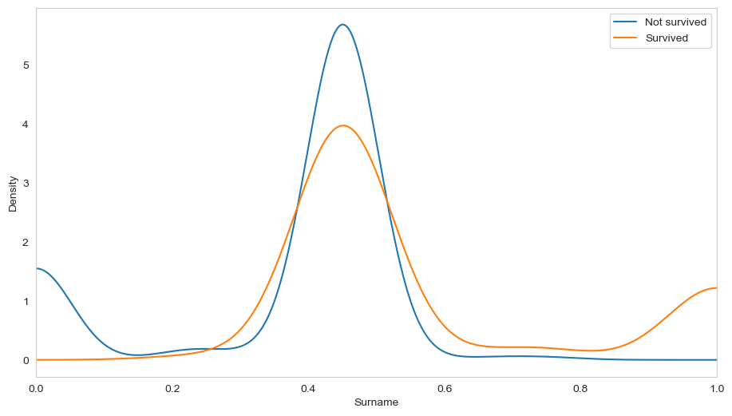

```python
plt.figure(figsize=(11, 6))
df_train[df_train['Survived'] == 0]['Family_survivers'].plot(kind='kde', label = 'Not survived')
df_train[df_train['Survived'] == 1]['Family_survivers'].plot(kind='kde', label = 'Survived')
plt.legend()
plt.grid()
plt.xlabel('Surname')
plt.xlim(0, 1)
```

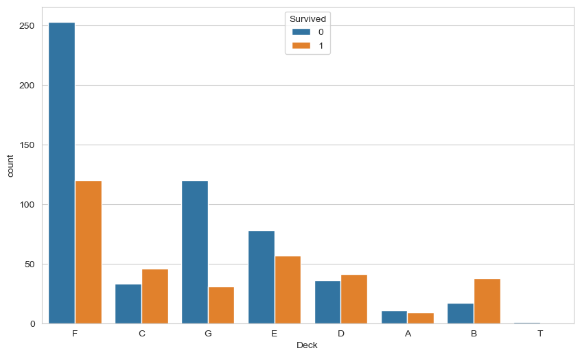

```python
# Which deck had the best survival rate?
sns.countplot(data=df_train, x='Deck', hue='Survived')
```

```python
# Target encoding on Deck
target_encoder = TargetEncoder()
df_train['Deck_Encoded'] = target_encoder.fit_transform(df_train['Deck'], df_train['Survived'])
df_test['Deck_Encoded'] = target_encoder.transform(df_test['Deck'])
```

We start by looking at the correlation between the features and the target

```python
df_train.corrwith(df_train.Survived).abs().sort_values(ascending=False)
```

```
Survived                   1.000000
Sex_male                   0.543351
Family_survivers           0.471830
Status_Man                 0.471544
Status_Woman               0.411028
Pclass_3                   0.322308
Deck_Encoded               0.280247
Price_paid                 0.273556
FareBracketEncode          0.264887
Fare                       0.257307
IsAlone                    0.203367
Status_Mother              0.199964
Embarked_S                 0.149683
IsTravellingWithParents    0.147408
Status_Father              0.121574
AgeBracket                 0.106238
Pclass_2                   0.093349
Parch                      0.081629
Same_ticket                0.070293
Age                        0.059160
SibSp                      0.035322
HasLargeFamily             0.029945
FamilySize                 0.016639
Embarked_Q                 0.003650
dtype: float64
```

Now we want to drop features that are highly correlated with each other, as they don't add much information

```python
features_to_drop = [
    "Name", "Fare",
    #"Same_ticket",
    "Ticket", "Cabin",
    "Title", "Survived",
    "Age", "FamilySize",
    "SibSp", "Parch", # These correlate with HasLargeFamily since they were used to create it
    "Embarked_Q", # This has a very low correlation with Survived
    "Deck",
    "Ticket_number", "LastName", "Ticket_ref",
    "FareBracket", "Price_paid"
]
```

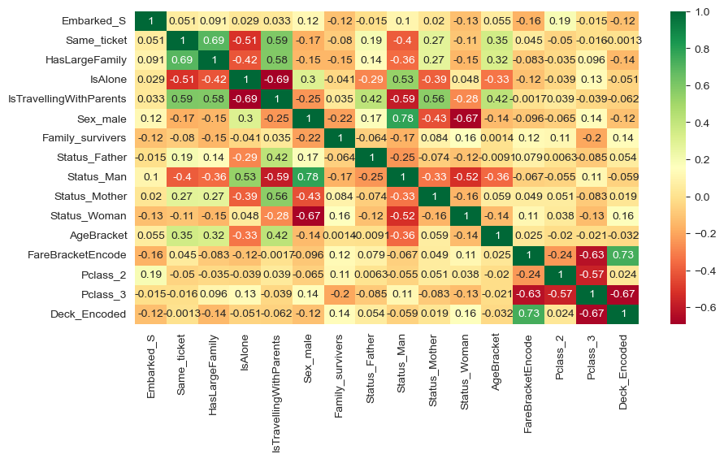

```python
# Find highly correlated features
corr = df_train.drop(features_to_drop, axis=1).corr()
plt.figure(figsize=(10, 5))
sns.heatmap(corr, annot=True, cmap="RdYlGn")
plt.show()
```

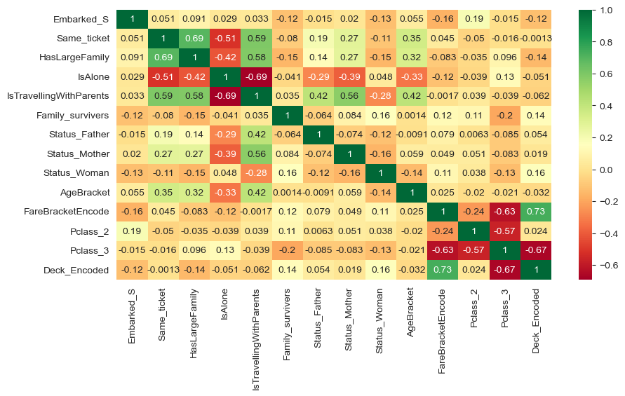

```python
features_to_drop.extend(['Sex_male', 'Status_Man'])
corr = df_train.drop(features_to_drop, axis=1).corr()
plt.figure(figsize=(10, 5))
sns.heatmap(corr, annot=True, cmap="RdYlGn")
plt.show()
```

## Model Training

We drop unnecessary columns and split the data into training and testing sets

```python
y = df_train['Survived']
X = df_train.drop(features_to_drop, axis=1)

X_train, X_test, y_train, y_test = train_test_split(X, y, test_size=0.3, random_state=42)

X_val, X_test, y_val, y_test = train_test_split(X_test, y_test, test_size=0.5, random_state=42)

features_to_drop.remove('Survived')
X_submission = df_test.drop(features_to_drop, axis=1)
```

```python
model_results = pd.DataFrame(columns=['Model', 'Accuracy', 'Precision', 'Recall', 'F1', 'AUC'])
```

### XGBoost Classifier with GridSearchCV

```python
param_grid = {
    "max_depth": [3, 4, 5, 7],
    "learning_rate": [0.1, 0.01, 0.05],
    "gamma": [0, 0.25, 1],
    "reg_lambda": [0, 1, 10],
    "scale_pos_weight": [1, 3, 5],
    "subsample": [0.8],
    "colsample_bytree": [0.5],
}
```

```python
from sklearn.model_selection import GridSearchCV

# Init classifier
xgb_cl = XGBClassifier(n_estimators=100, random_state=42, n_jobs=-1)

# Init Grid Search
grid_cv = GridSearchCV(xgb_cl, param_grid, n_jobs=-1, cv=3, scoring="f1", refit=True, verbose=1)

# Fit
_ = grid_cv.fit(X_train, y_train)
```

```
Fitting 3 folds for each of 324 candidates, totalling 972 fits
```

```python
grid_cv.best_score_
```

```
0.7638150390453627
```

```
F1 score on training set:  0.8066825775656324
F1 score on test set:  0.7142857142857143
Accuracy score on test set:  0.8208955223880597
```

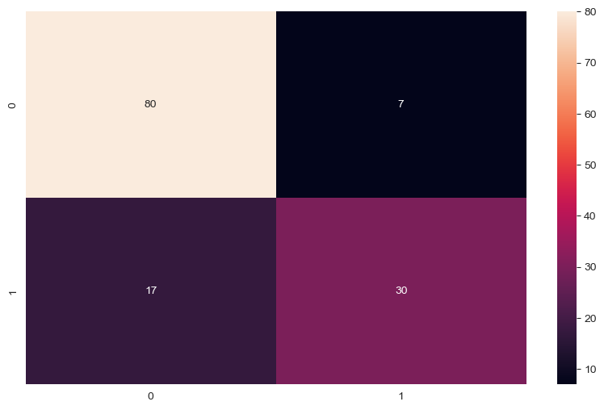

```python
from sklearn.metrics import precision_score, recall_score, roc_auc_score


xgb_clf = grid_cv.best_estimator_

y_pred = xgb_clf.predict(X_test)
print("F1 score on training set: ", f1_score(y_train, xgb_clf.predict(X_train)))
print("F1 score on test set: ", f1_score(y_test, y_pred))
print("Accuracy score on test set: ", accuracy_score(y_test, y_pred))
cm = confusion_matrix(y_test, y_pred)
sns.heatmap(cm, annot=True, fmt="d")
model_results = model_results.append({
    'Model': 'XGBoost with GridSearchCV',
    'Accuracy': accuracy_score(y_test, y_pred),
    'Precision': precision_score(y_test, y_pred),
    'Recall': recall_score(y_test, y_pred),
    'F1': f1_score(y_test, y_pred),
    'AUC': roc_auc_score(y_test, y_pred)
}, ignore_index=True)
```

```
F1 score on training set:  0.8995433789954337
F1 score on test set:  0.6896551724137931
Accuracy score on test set:  0.7985074626865671
```

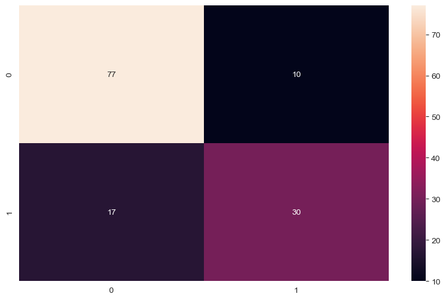

```python
xgb_clf = XGBClassifier(
    n_estimators=1000,
    learning_rate=0.05,
    n_jobs=-1)
xgb_clf.fit(X_train, y_train)
y_pred = xgb_clf.predict(X_test)
print("F1 score on training set: ", f1_score(y_train, xgb_clf.predict(X_train)))
print("F1 score on test set: ", f1_score(y_test, y_pred))
print("Accuracy score on test set: ", accuracy_score(y_test, y_pred))
cm = confusion_matrix(y_test, y_pred)
sns.heatmap(cm, annot=True, fmt="d")

model_results = model_results.append({
    'Model': 'XGBoost default',
    'Accuracy': accuracy_score(y_test, y_pred),
    'Precision': precision_score(y_test, y_pred),
    'Recall': recall_score(y_test, y_pred),
    'F1': f1_score(y_test, y_pred),
    'AUC': roc_auc_score(y_test, y_pred)
}, ignore_index=True)
```

Stacking Classifier

```
F1 score on training set:  0.7972350230414746
F1 score on test set:  0.7272727272727273
Accuracy score on test set:  0.8208955223880597
```

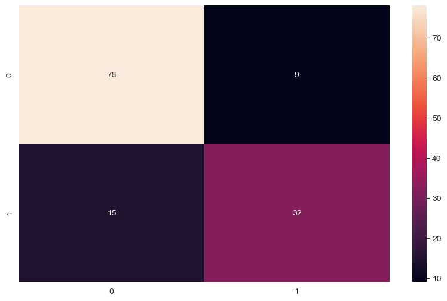

```python
from sklearn.calibration import LinearSVC
from sklearn.ensemble import StackingClassifier
from sklearn.pipeline import make_pipeline


estimators = [
    ('rf', RandomForestClassifier(n_estimators=10, random_state=42)),
    ('svr', make_pipeline(StandardScaler(), LinearSVC(random_state=42))),
    ('lgr', LogisticRegression())
 ]

clf = StackingClassifier(
     estimators=estimators,
     final_estimator=XGBClassifier(n_estimators=100, random_state=42, learning_rate=0.05, n_jobs=-1)
)
clf.fit(X_train, y_train)
y_pred = clf.predict(X_test)
print("F1 score on training set: ", f1_score(y_train, clf.predict(X_train)))
print("F1 score on test set: ", f1_score(y_test, y_pred))
print("Accuracy score on test set: ", accuracy_score(y_test, y_pred))
cm = confusion_matrix(y_test, y_pred)
sns.heatmap(cm, annot=True, fmt="d")
```

```python
# Who did we get wrong?
wrong = X_test[y_test != y_pred]
df_analysis = df_train.copy().loc[X_test.index]
df_analysis['Predicted'] = y_pred
```

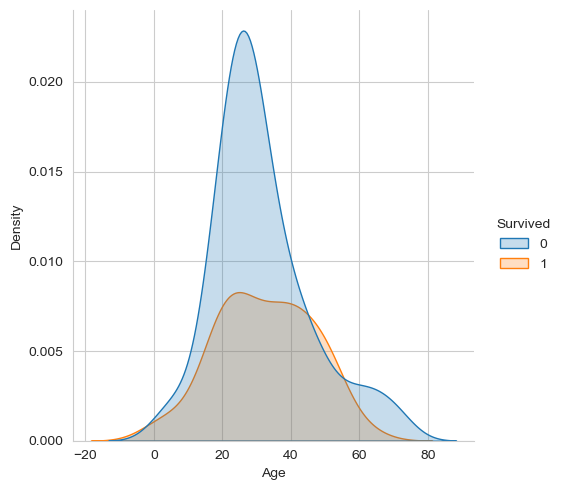

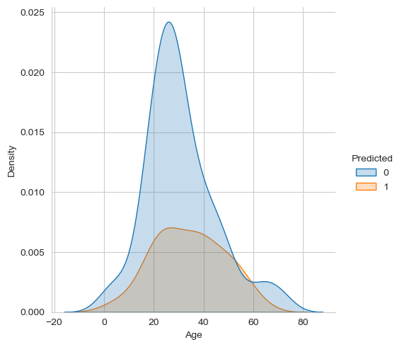

```python
sns.displot(df_analysis, x="Age", hue="Survived", kind="kde", fill=True)
sns.displot(df_analysis, x="Age", hue="Predicted", kind="kde", fill=True)
```

## Prepare for submission

We have one missing value in the Fare column

```python
X_submission.shape
```

```
(418, 14)
```

```python
submission = pd.DataFrame({
        "PassengerId": passenger_id,
        "Survived": clf.predict(X_submission)
    })
submission.to_csv(f'Prediction_{pd.Timestamp.now()}.csv'.replace(' ', '_').replace(':', '_'), index=False)
```

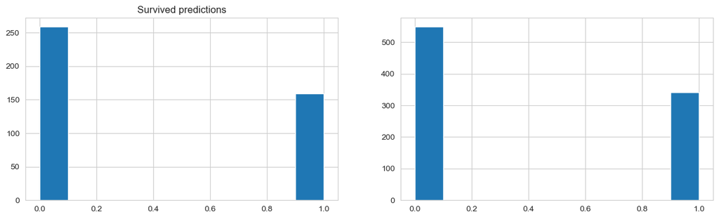

```python
fig, (axis1,axis2) = plt.subplots(1,2,figsize=(15,4))

submission.Survived.hist(ax=axis1)
axis1.set_title('Survived predictions')
df_train.Survived.hist(ax=axis2)
```

```python
X_submission.head(5)
```

|  | Embarked_S | Same_ticket | HasLargeFamily | IsAlone | IsTravellingWithParents | Family_survivers | Status_Father | Status_Mother | Status_Woman | AgeBracket | FareBracketEncode | Pclass_2 | Pclass_3 | Deck_Encoded |
| --- | --- | --- | --- | --- | --- | --- | --- | --- | --- | --- | --- | --- | --- | --- |
| 891 | 0 | 1 | 0 | 1 | 0 | 0.75 | 0 | 0 | 0 | 4 | 0.31 | 0 | 1 | 0.42 |
| 892 | 1 | 1 | 0 | 0 | 0 | 0.45 | 0 | 0 | 1 | 3 | 0.31 | 0 | 1 | 0.42 |
| 893 | 0 | 1 | 0 | 1 | 0 | 0.45 | 0 | 0 | 0 | 1 | 0.31 | 1 | 0 | 0.53 |
| 894 | 1 | 1 | 0 | 1 | 0 | 0.45 | 0 | 0 | 0 | 2 | 0.31 | 0 | 1 | 0.21 |
| 895 | 1 | 2 | 0 | 0 | 1 | 1.00 | 0 | 1 | 0 | 2 | 0.31 | 0 | 1 | 0.32 |